[figure not shown]

# PWP CIA 3

# Online Shopper's Intention

#### Sanoop C S - 1927908

## Business Understanding:

The increasing popularity of online shopping has led to the emergence of new economic activities. To succeed in the highly competitive e-commerce environment, it is vital to understand consumer intention. Understanding what motivates consumer intention is critical because such intention is key to survival in this fast-paced and hypercompetitive environment.

```python
# For basic operations
import numpy as np
import pandas as pd

# For data visualizations
import matplotlib.pyplot as plt
import seaborn as sns
```

## Dataset Information:

The dataset consists of feature vectors belonging to 12,330 sessions. The dataset was formed so that each session would belong to a different user in a 1-year period to avoid any tendency to a specific campaign, special day, user profile, or period.

### Attribute Information:

```
1. The dataset consists of 10 numerical, 8 categorical attributes & 12330 observations.
2. The 'Revenue' attribute can be used as the class label.
```

```python
# Reading the dataset

data = pd.read_csv("C:\\Users\\sanoo\\OneDrive\\Desktop\\Capstone_final\\online_shoppers_intention.csv")
```

## Data understanding:

```python
# Checking the type

type(data)
```

```
pandas.core.frame.DataFrame
```

```python
# Checking the head of the data

data.head()
```

|  | Administrative | Administrative_Duration | Informational | Informational_Duration | ProductRelated | ProductRelated_Duration | BounceRates | ExitRates | PageValues | SpecialDay | Month | OperatingSystems | Browser | Region | TrafficType | VisitorType | Weekend | Revenue |
| --- | --- | --- | --- | --- | --- | --- | --- | --- | --- | --- | --- | --- | --- | --- | --- | --- | --- | --- |
| 0 | 0.0 | 0.0 | 0.0 | 0.0 | 1.0 | 0.000000 | 0.20 | 0.20 | 0.0 | 0.0 | Feb | 1 | 1 | 1 | 1 | Returning_Visitor | False | False |
| 1 | 0.0 | 0.0 | 0.0 | 0.0 | 2.0 | 64.000000 | 0.00 | 0.10 | 0.0 | 0.0 | Feb | 2 | 2 | 1 | 2 | Returning_Visitor | False | False |
| 2 | 0.0 | -1.0 | 0.0 | -1.0 | 1.0 | -1.000000 | 0.20 | 0.20 | 0.0 | 0.0 | Feb | 4 | 1 | 9 | 3 | Returning_Visitor | False | False |
| 3 | 0.0 | 0.0 | 0.0 | 0.0 | 2.0 | 2.666667 | 0.05 | 0.14 | 0.0 | 0.0 | Feb | 3 | 2 | 2 | 4 | Returning_Visitor | False | False |
| 4 | 0.0 | 0.0 | 0.0 | 0.0 | 10.0 | 627.500000 | 0.02 | 0.05 | 0.0 | 0.0 | Feb | 3 | 3 | 1 | 4 | Returning_Visitor | True | False |

```python
# Describing the data

data.describe()
```

|  | Administrative | Administrative_Duration | Informational | Informational_Duration | ProductRelated | ProductRelated_Duration | BounceRates | ExitRates | PageValues | SpecialDay | OperatingSystems | Browser | Region | TrafficType |
| --- | --- | --- | --- | --- | --- | --- | --- | --- | --- | --- | --- | --- | --- | --- |
| count | 12316.000000 | 12316.000000 | 12316.000000 | 12316.000000 | 12316.000000 | 12316.000000 | 12316.000000 | 12316.000000 | 12330.000000 | 12330.000000 | 12330.000000 | 12330.000000 | 12330.000000 | 12330.000000 |
| mean | 2.317798 | 80.906176 | 0.503979 | 34.506387 | 31.763884 | 1196.037057 | 0.022152 | 0.043003 | 5.889258 | 0.061427 | 2.124006 | 2.357097 | 3.147364 | 4.069586 |
| std | 3.322754 | 176.860432 | 1.270701 | 140.825479 | 44.490339 | 1914.372511 | 0.048427 | 0.048527 | 18.568437 | 0.198917 | 0.911325 | 1.717277 | 2.401591 | 4.025169 |
| min | 0.000000 | -1.000000 | 0.000000 | -1.000000 | 0.000000 | -1.000000 | 0.000000 | 0.000000 | 0.000000 | 0.000000 | 1.000000 | 1.000000 | 1.000000 | 1.000000 |
| 25% | 0.000000 | 0.000000 | 0.000000 | 0.000000 | 7.000000 | 185.000000 | 0.000000 | 0.014286 | 0.000000 | 0.000000 | 2.000000 | 2.000000 | 1.000000 | 2.000000 |
| 50% | 1.000000 | 8.000000 | 0.000000 | 0.000000 | 18.000000 | 599.766190 | 0.003119 | 0.025124 | 0.000000 | 0.000000 | 2.000000 | 2.000000 | 3.000000 | 2.000000 |
| 75% | 4.000000 | 93.500000 | 0.000000 | 0.000000 | 38.000000 | 1466.479902 | 0.016684 | 0.050000 | 0.000000 | 0.000000 | 3.000000 | 2.000000 | 4.000000 | 4.000000 |
| max | 27.000000 | 3398.750000 | 24.000000 | 2549.375000 | 705.000000 | 63973.522230 | 0.200000 | 0.200000 | 361.763742 | 1.000000 | 8.000000 | 13.000000 | 9.000000 | 20.000000 |

## Data Preparation/Data cleaning:

```python
# Checking the no. of null values in data after imputing the missing values

data.isnull().sum().sum()
```

```
112
```

```python
# Inputing Missing Values with 0

data.fillna(0, inplace = True)
```

```python
#Again checking for missing values

data.isnull().sum().sum()
```

```
0
```

## Data Visualization:

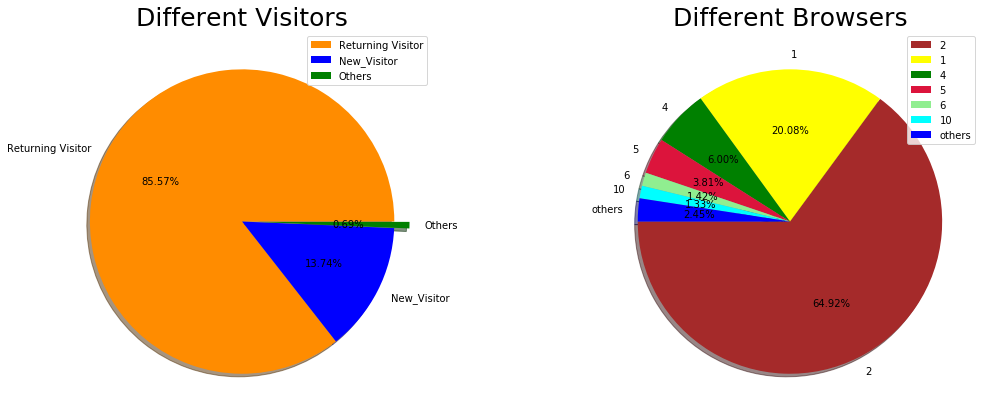

```python
# Plotting a pie chart for browsers

plt.rcParams['figure.figsize'] = (18, 7)
size = [10551, 1694, 85]
colors = ['darkorange', 'blue', 'green']
labels = "Returning Visitor", "New_Visitor", "Others"
explode = [0, 0, 0.1]
plt.subplot(1, 2, 1)
plt.pie(size, colors = colors, labels = labels, explode = explode, shadow = True, autopct = '%.2f%%')
plt.title('Different Visitors', fontsize = 25)
plt.axis('off')
plt.legend()

# plotting a pie chart for browsers
size = [7961, 2462, 736, 467,174, 163, 300]
colors = ['brown', 'yellow', 'green', 'crimson', 'lightgreen', 'cyan', 'blue']
labels = "2", "1","4","5","6","10","others"

plt.subplot(1, 2, 2)
plt.pie(size, colors = colors, labels = labels, shadow = True, autopct = '%.2f%%', startangle = 180)
plt.title('Different Browsers', fontsize = 25)
plt.axis('off')
plt.legend()
plt.show()
```

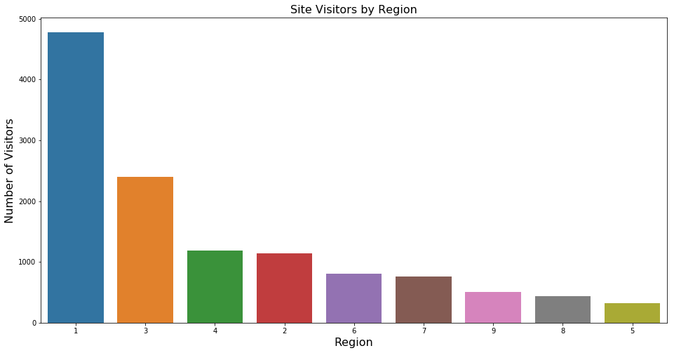

```python
# What region do shoppers come from?

plt.figure(figsize = (16,8))
sns.countplot(x = "Region", data = data,
              order = data['Region'].value_counts().index)
plt.title("Site Visitors by Region", fontsize = 16)
plt.xlabel("Region", fontsize = 16)
plt.ylabel("Number of Visitors", fontsize = 16)
```

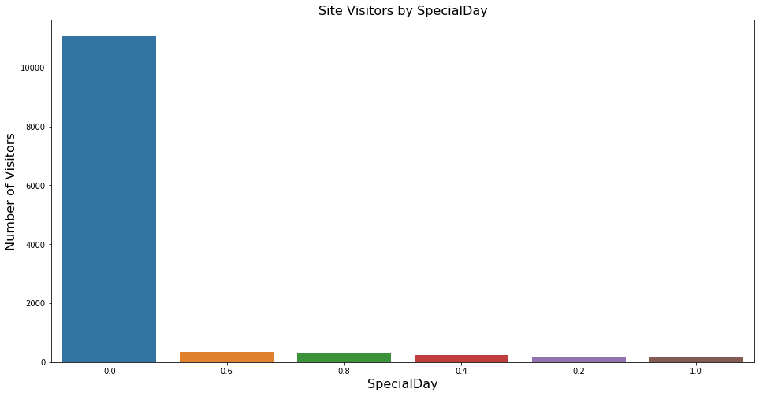

```python
# SpecialDay vs No of Visitor's

plt.figure(figsize = (16,8))
sns.countplot(x = "SpecialDay", data = data,
              order = data['SpecialDay'].value_counts().index)
plt.title("Site Visitors by SpecialDay", fontsize = 16)
plt.xlabel("SpecialDay", fontsize = 16)
plt.ylabel("Number of Visitors", fontsize = 16)
```

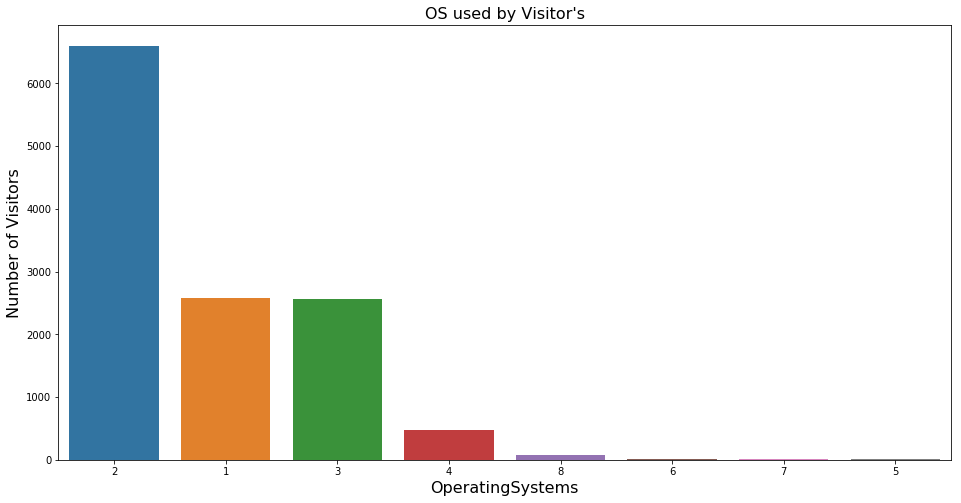

```python
# Different Operating Systems used by Visitor's

plt.figure(figsize = (16,8))
sns.countplot(x = "OperatingSystems", data = data,
              order = data['OperatingSystems'].value_counts().index)
plt.title("OS used by Visitor's", fontsize = 16)
plt.xlabel("OperatingSystems", fontsize = 16)
plt.ylabel("Number of Visitors", fontsize = 16)
```

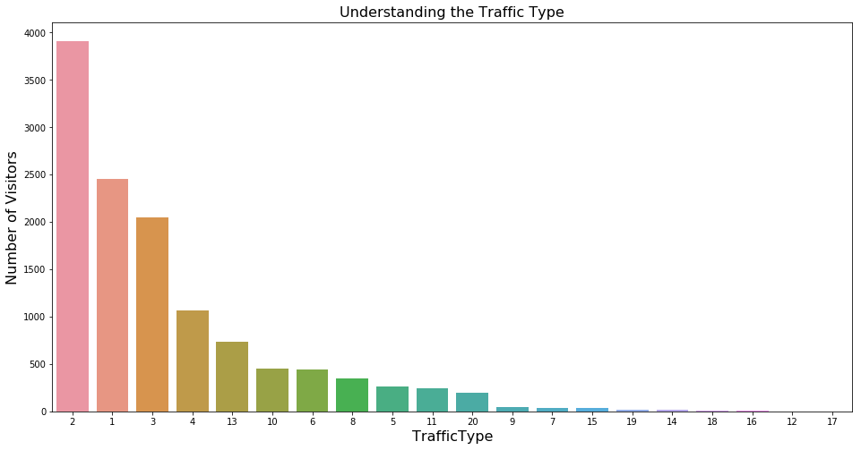

```python
# Graph to understand the traffic type

plt.figure(figsize = (16,8))
sns.countplot(x = "TrafficType", data = data,
              order = data['TrafficType'].value_counts().index)
plt.title("Understanding the Traffic Type", fontsize = 16)
plt.xlabel("TrafficType", fontsize = 16)
plt.ylabel("Number of Visitors", fontsize = 16)
```

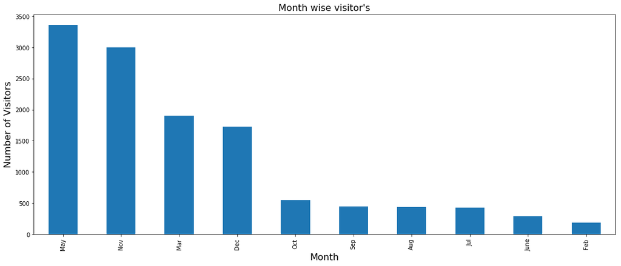

```python
# Month wise visitor's

data['Month'].value_counts().plot(kind = "bar")
plt.xticks(rotation = 90)
plt.title("Month wise visitor's", fontsize = 16)
plt.xlabel("Month", fontsize = 16)
plt.ylabel("Number of Visitors", fontsize = 16)
plt.show()
```

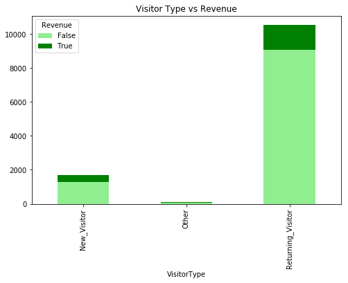

```python
# Visitor type vs revenue

data = pd.crosstab(data['VisitorType'], data['Revenue'])
data.plot(kind = 'bar', stacked = True, figsize = (8, 5), color = ['lightgreen', 'green'])
plt.title('Visitor Type vs Revenue')
plt.show()
```

## Deriving useful insights:

1. The returning visitor's are more in number which contributes to around 85.57% than new visitor's and others.
2. Majority of visitor's are browsing from browser 2 followed by 1.
3. Majority of visitor's are coming from region 1 followed by 3.
4. Most of the visitor's are visiting the site when it os not a special day.
5. The visitor's are more in number who uses type 2 operating system.
6. May and November month contribute's to the most number of site visitor's.
7. Returning visitor's contributes more to the revenue followed by new visitor's.